# Buses to and from the University of Auckland

## What’s going on with this data?

## Nature of Data

This dataset contains information about trends and patterns across different Auckland Transport buses that go to and from the University of Auckland. It includes variables such as:

- **Day** — a categorical variable that records the day of the week when the trip occurred (*Monday* to *Sunday*).
- **Time** — the specific time the rider rode the bus, used to explore temporal patterns in punctuality and busyness.
- **Bus punctuality** — a numeric variable that measures how early or late a bus arrives compared to its scheduled arrival time. Positive values indicate lateness, and negative values indicate early arrivals.
- **Busyness level** — a categorical variable with four levels: *empty bus*, *slightly full bus*, *moderately full bus*, and *full bus*, indicating how crowded the bus was during the trip.
- **Experience** — a numeric variable ranging from 1 to 10, representing the rider’s self-reported experience with the bus service.

The goal of this analysis is to investigate how time, day, and busyness affect both bus punctuality and rider experience. By visualising these relationships, we aim to understand when service quality drops and how that impacts rider satisfaction.

## Average Bus Punctuality by Busyness level

Let’s see how the Bus Punctuality correlates to Busyness level of the bus.

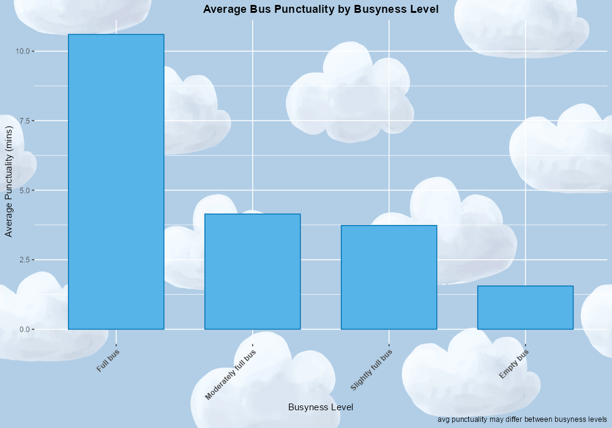

Bar chart showing Average Bus Punctuality by Busyness Level

As we can see, on average, buses that are more full tend to be more late. That makes sense, as busier buses often require more time for passengers to board and disembark, leading to delays.

## Average Experience by Busyness Level

On the same topic of Busyness level, now let’s see how Passenger experience correlates to Busyness level of the bus

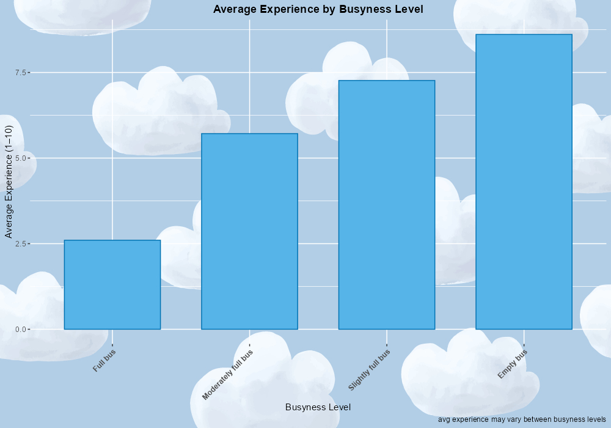

Bar chart showing Average Experience by Busyness Leve

On average, the emptier a bus is, the higher the passenger experience tends to be. This makes sense, as a less crowded bus usually provides more comfort, space, and a quieter environment for riders.

## Average Bus Punctuality by Day

We could wonder how Bus Punctuality differs by days of the week.

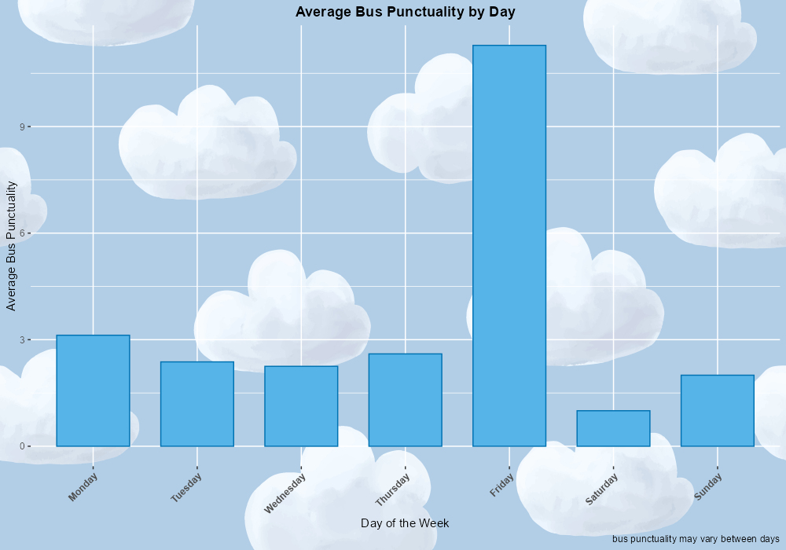

Bar chart that shows Average Bus Punctuality by Day

Interesting, Friday seems to have on average much later buses compared to other days.

## Relationship Between Busyness, Punctuality and Rider Satisfaction

Let’s now see how some factors together would affect the Experience and so the Rider satisfaction. Let’s look at what we have used so far, Busyness level and Punctuality.

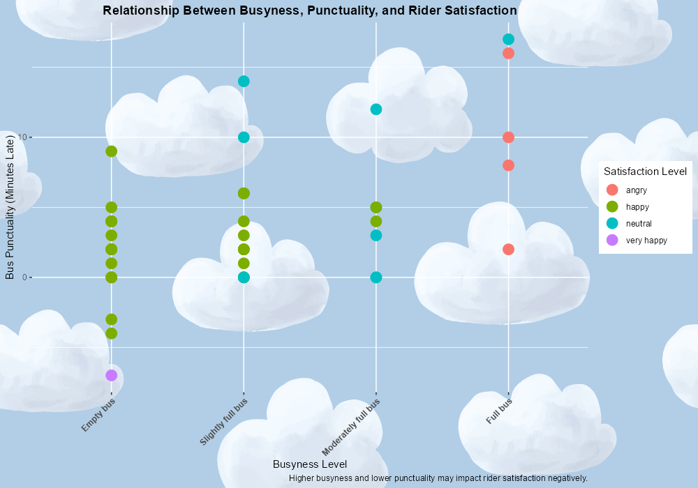

Dot plot that shows the relationship between Busyness, Punctuality and Rider Satisfaction

As expected, we see that there is a general positive Rider satisfaction for buses that are early/on-time and Empty compared to those buses that are Late and Full which are negative.

## Timestamp

Let’s see how responses change by Day.

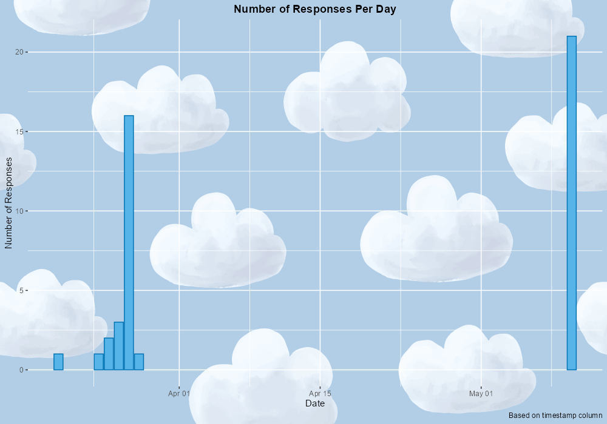

There is a big gap in the middle, this is because no responses were made from the time Project 2 finished to when Project 4 was released. For those days that see a high peak before Apr 01, it is due to responses from the form all being entered at once because respondent couldn’t fill out form live but rather all in one day from notes made during the week. The high peak after May 01 is due to opening the form to multiple people in which they all completed in one day.